# Validating primary and hospital care resource use and costs based on OMOP-mapped CPRD data against corresponding source data: the case of postmenopausal fragility fractures in the UK

Njoki Njuki, Gianluca Fabiano

Wednesday, 12 March 2025

# Objectives

To assess the validity of primary and hospital care resource use and costs estimated based on OMOP-mapped CPRD data against its corresponding source data using a cohort of women with postmenopausal fragility fractures in the UK.

The cohort of interest is made of women aged >50 years with an incident fragility fracture in any site except the face, skull or digits and no history of fracture in the two years prior. The outcomes of interest are *primary* and *secondary healthcare resource utilisation* and *direct costs* associated to first incident fracture measured during the 730 days post index date or until a censoring event occurs and expressed as values per person/year. A detailed analysis plan for this study is available [here](https://github.com/LucyNjokiNjuki/OMOP-Validation-Study/raw/refs/heads/main/Analysis_plan_V.2_final.docx).

This RMarkdown reports the data preparation and results for the analysis conducted on the *source CPRD-HES* dataset.

# Data Preparation

The attrition table below shows the steps we followed to clean and prepare the data for the analysis.

## Attrition Report

### Raw

**Attrition table**

| Reason for exclusion | Number of records | Number of subjects | N subjects excluded | Perc subjects excluded (%) | N records excluded |
| --- | --- | --- | --- | --- | --- |
| Had their 1st fx >= 01/04/2012 and <= 31/03/2018 when they were > 50 years old | 57,617 | 31,217 |  |  |  |
| Excluding fracture happening before the birth year | 57,617 | 31,217 | 0 | 0 | 0 |
| Excluding records that happen outside of study period | 53,050 | 31,217 | 0 | 0 | 4,567 |
| Excluding records that happen outside of observation period | 53,003 | 31,192 | 25 | 0.08 | 47 |
| Excluding trauma fractures (same day as trauma codes or 3 distinct fracture sites on the same date | 47,097 | 30,543 | 649 | 2.08 | 5,906 |
| Excluding fractures on the same day as death or after death | 47,086 | 30,536 | 7 | 0.02 | 11 |
| Clean out using washout period | 35,926 | 30,536 | 0 | 0 | 11,160 |
| Excluding records on the same day for the same person according to hierarchy (Hip, Spine, NHNS) | 33,957 | 30,536 | 0 | 0 | 1,969 |
| Excluding not female individuals | 33,957 | 30,536 | 0 | 0 | 0 |
| Excluding individuals without fracture records | 33,957 | 30,536 | 0 | 0 | 0 |
| Excluding index fractures that happen on the last day of observation period | 30,528 | 30,528 | 8 | 0.03 | 3,429 |
| Excluding records with insufficient prior observation and/or outside of observation period | 27,078 | 27,078 | 3,450 | 11.3 | 3,450 |
| Excluding records of index fractures where the subject has not turned 50 | 27,078 | 27,078 | 0 | 0 | 0 |
| Excluding records happened after cancer | 25,264 | 25,264 | 1,814 | 6.7 | 1,814 |
| Excluding records happened after metabolic bone diseases | 25,138 | 25,138 | 126 | 0.5 | 126 |

### OMOP

**Attrition table**

| Reason for exclusion | Number of records | Number of subjects | N subjects excluded | Perc subjects excluded (%) | N records excluded |
| --- | --- | --- | --- | --- | --- |
| Starting Population - Female individuals | 583378 | 583378 |  |  |  |
| Anyone With Fracture(s) | 426102 | 151875 | 431503 | 284.12 | 157276 |
| Had their 1st fx >= 01/04/2012 and <= 31/03/2018 when they were > 50 years old | 85445 | 30847 | 121028 | 392.35 | 340657 |
| Excluding fracture happening before the birth year | 85445 | 30847 | 0 | 0 | 0 |
| Excluding records that happen outside of study period | 75811 | 30847 | 0 | 0 | 9634 |
| Excluding records that happen outside of observation period | 75750 | 30823 | 24 | 0.08 | 61 |
| Excluding trauma fractures (same day as trauma codes or 3 distinct fracture sites on the same date | 73133 | 30045 | 778 | 2.59 | 2617 |
| Excluding fractures on the same day as death or after death | 73122 | 30040 | 5 | 0.02 | 11 |
| Clean out using washout period | 41082 | 30040 | 0 | 0 | 32040 |
| Excluding records on the same day for the same person according to hierarchy (Hip, Spine, NHNS) | 39029 | 30040 | 0 | 0 | 2053 |
| Excluding not female individuals | 39029 | 30040 | 0 | 0 | 0 |
| Excluding individuals without fracture records | 39029 | 30040 | 0 | 0 | 0 |
| Excluding index fractures that happen on the last day of observation period | 30039 | 30039 | 1 | 0 | 8990 |
| Excluding records with insufficient prior observation and/or outside of observation period | 26645 | 26645 | 3394 | 12.74 | 3394 |
| Excluding records of index fractures where the subject has not turned 50 | 26645 | 26645 | 0 | 0 | 0 |
| Excluding records happened after cancer | 23550 | 23550 | 3095 | 13.14 | 3095 |
| Excluding records happened after metabolic bone diseases | 23386 | 23386 | 164 | 0.7 | 164 |

# Results

## Table 1

### Raw

**Patient Characteristics**<sup>1</sup>

| Variable | N = 25,138 |
| --- | --- |
| Age at Fracture Occurrence | 71 (61, 81) |
| Fracture Site |  |
| Hip | 3,532 (14%) |
| Vertebra | 1,311 (5.2%) |
| NHNV | 20,295 (81%) |
| Censoring Event |  |
| Max of 730 days from index date | 18,726 (74%) |
| End of data collection period | 2,267 (9.0%) |
| Fracture ensuing incident (index) fracture | 1,815 (7.2%) |
| Death | 1,695 (6.7%) |
| Cancer | 552 (2.2%) |
| Paget’s disease of the bone, or other metabolic bone diseases | 74 (0.3%) |
| Max of 730 days from index date, End of data collection period | 3 (<0.1%) |
| Cancer, Fracture ensuing incident (index) fracture | 1 (<0.1%) |
| End of data collection period, Cancer | 1 (<0.1%) |
| End of data collection period, Fracture ensuing incident (index) fracture | 1 (<0.1%) |
| Max of 730 days from index date, Cancer | 1 (<0.1%) |
| Max of 730 days from index date, Fracture ensuing incident (index) fracture | 1 (<0.1%) |
| Max of 730 days from index date, Paget’s disease of the bone, or other metabolic bone diseases | 1 (<0.1%) |
| Follow up Time | 730 days (709 days, 730 days) |
| User Status<sup>2</sup> |  |
| Non-User | 517 (2.1%) |
| User | 24,621 (98%) |
| Non-user Visit Status |  |
| No Visits | 13 (2.5%) |
| Visits with Non-clinically Relevant Staff | 504 (97%) |

<sup>1</sup> Median (Q1, Q3); n (%)  
<sup>2</sup> *User defined as subjects with >=1 visit with a clinically relevant healthcare provider and Non-User as Subjects with no visits, or visits with non-clinically relevant healthcare provider*

### OMOP

**Patient Characteristics**<sup>1</sup>

| Variable | N = 23,386 |
| --- | --- |
| Age at Fracture Occurrence | 70 (61, 81) |
| Fracture Site |  |
| Hip | 3,173 (14%) |
| Vertebra | 1,682 (7.2%) |
| NHNV | 18,531 (79%) |
| Censoring event |  |
| Max of 730 days from index date | 15,411 (66%) |
| Fracture ensuing incident (index) fracture | 4,036 (17%) |
| End of data collection period | 1,838 (7.9%) |
| Death | 1,266 (5.4%) |
| Cancer | 745 (3.2%) |
| Paget’s disease of the bone, or other metabolic bone diseases | 78 (0.3%) |
| Cancer, Fracture ensuing incident (index) fracture | 2 (<0.1%) |
| End of data collection period, Fracture ensuing incident (index) fracture | 2 (<0.1%) |
| Max of 730 days from index date, End of data collection period | 2 (<0.1%) |
| Cancer, Paget’s disease of the bone, or other metabolic bone diseases | 1 (<0.1%) |
| End of data collection period, Cancer | 1 (<0.1%) |
| Max of 730 days from index date, Cancer | 1 (<0.1%) |
| Max of 730 days from index date, Fracture ensuing incident (index) fracture | 1 (<0.1%) |
| Max of 730 days from index date, Paget’s disease of the bone, or other metabolic bone diseases | 1 (<0.1%) |
| Paget’s disease of the bone, or other metabolic bone diseases, Fracture ensuing incident (index) fracture | 1 (<0.1%) |
| Follow up time | 730 (365, 730) |
| User Status<sup>2</sup> |  |
| Non-User | 1,014 (4.3%) |
| User | 22,372 (96%) |
| Non-user Visit Status |  |
| No Visits | 132 (13%) |
| Visits with Non-clinically Relevant Staff | 882 (87%) |

<sup>1</sup> Median (Q1, Q3); n (%)  
<sup>2</sup> *User defined as subjects with >=1 visit with a clinically relevant healthcare provider and Non-User as Subjects with no visits, or visits with non-clinically relevant healthcare provider*

## Primary care - Raw

### Healthcare resource utilisation (HCRU)

**All Patients - Visits per patient per year**

*Users and non-users*

| Mean | Minimum | Maximum | SD | Median | Lower Quartile | Upper Quartile |
| --- | --- | --- | --- | --- | --- | --- |
| 15.98 | 0 | 730.5 | 20.48 | 13.01 | 7.51 | 22.63 |

**Service users - Visits per patient per year**

*Subjects with >=1 visit with a clinically relevant healthcare provider*

| Mean | Minimum | Maximum | SD | Median | Lower Quartile | Upper Quartile |
| --- | --- | --- | --- | --- | --- | --- |
| 16.13 | 0.5 | 730.5 | 20.52 | 13.51 | 7.51 | 23.02 |

### HCRU Figures

Figure 1: Total number of primary care consultations

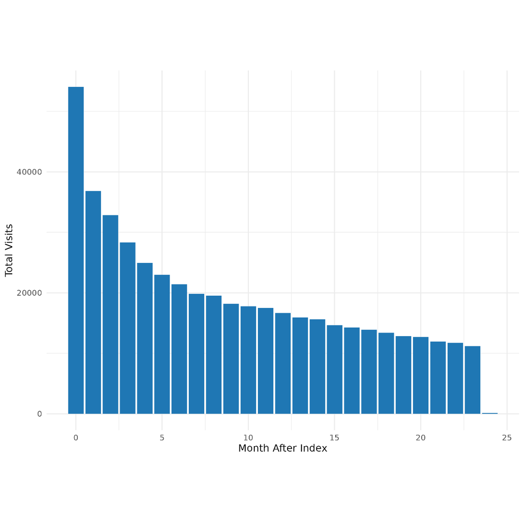

Figure 3: Exposure-weighted mean number of primary care consultations by provider specialty, users-only.

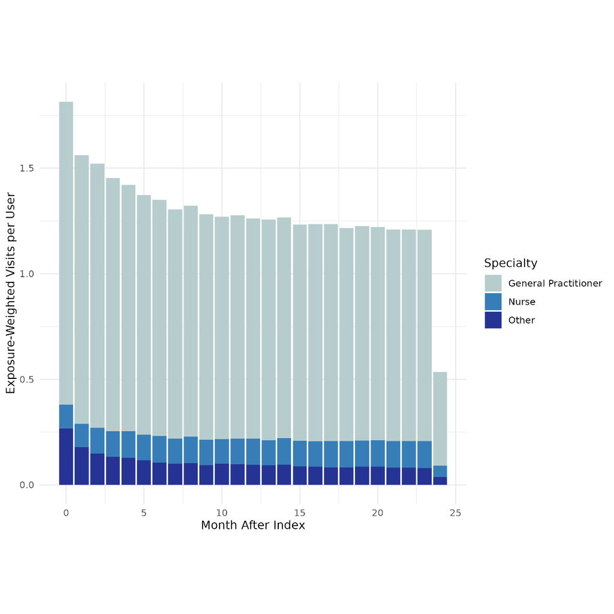

## Primary care - OMOP

### Healthcare resource utilisation (HCRU)

**All Patients - Visits per patient per year**

*Users and non-users*

| Mean | Minimum | Maximum | SD | Median | Lower Quartile | Upper Quartile |
| --- | --- | --- | --- | --- | --- | --- |
| 13.07 | 0 | 1441 | 32.25 | 10.86 | 4.93 | 21.22 |

**Service users - Visits per patient per year**

*Subjects with >=1 visit with a clinically relevant healthcare provider*

| Mean | Minimum | Maximum | SD | Median | Lower Quartile | Upper Quartile |
| --- | --- | --- | --- | --- | --- | --- |
| 13.47 | 0.49 | 1441 | 32.75 | 11.44 | 5.92 | 21.71 |

### HCRU Figures

Figure 1: Total number of primary care consultations

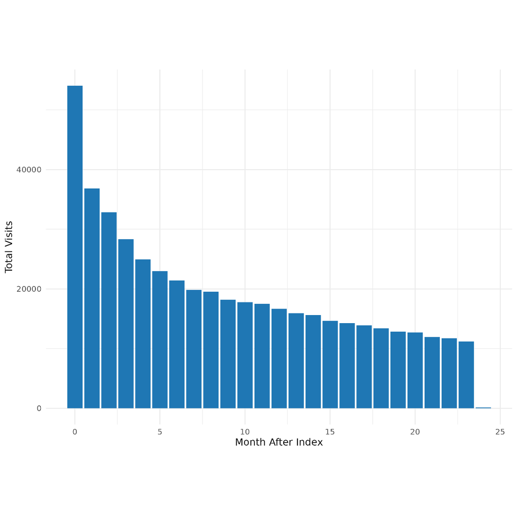

## Costs - Raw

### Costs Summary Results

**User Only Cost Summary Statistics**

*Subjects Who Visited a Clinically Relevant Consultant*

| Mean Visit Costs per Year | Minimum Visit Costs per Year | Maximum Visit Costs per Year | SD Visit Costs per Year | Median Visit Costs per Year | Lower Quartile Visit Costs per Year | Upper Quartile Visit Costs per Year |
| --- | --- | --- | --- | --- | --- | --- |
| 629.48 | 3 | 18846.2 | 768.82 | 525.36 | 297.55 | 903.62 |

**All Patients Costs Summary Statistics**

*Subjects Who Visited Both Clinically Relevant and Non-Relevant Consultants*

| Mean Visit Costs per Year | Minimum Visit Costs per Year | Maximum Visit Costs per Year | SD Visit Costs per Year | Median Visit Costs per Year | Lower Quartile Visit Costs per Year | Upper Quartile Visit Costs per Year |
| --- | --- | --- | --- | --- | --- | --- |
| 623.85 | 0 | 18846.2 | 767.76 | 514.63 | 286.98 | 890.39 |

### Cost Figures

Figure 4: Total number of primary care consultation costs

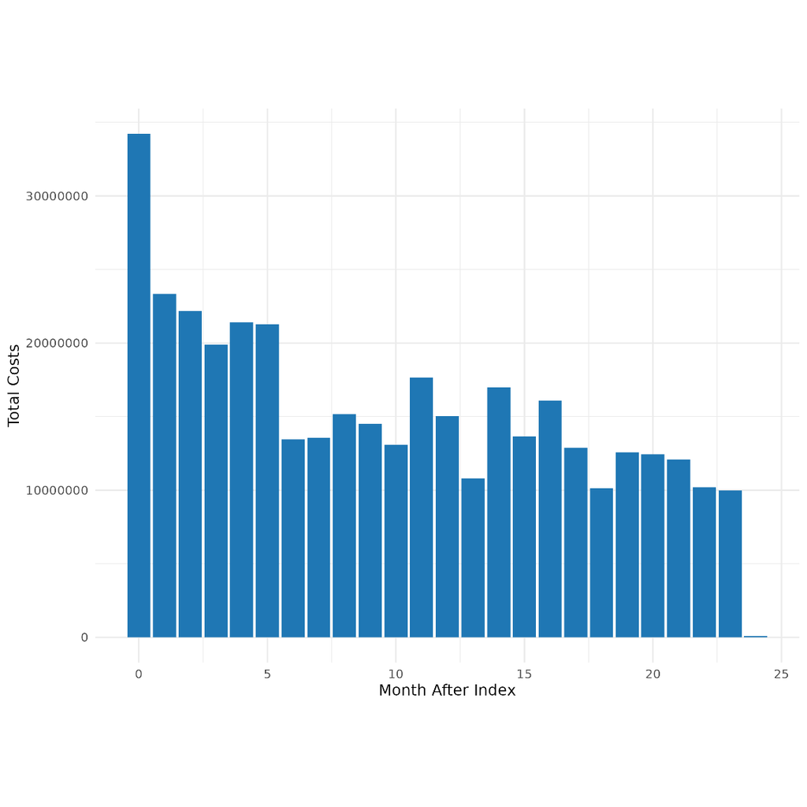

Figure 5: Mean number of primary care consultation costs by provider specialty, users-only.

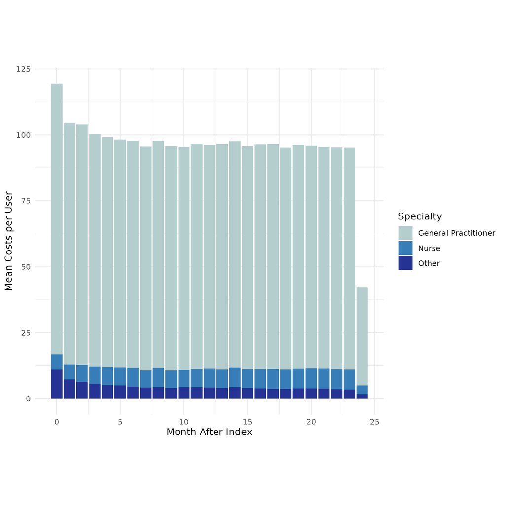

Figure 6: Exposure-weighted mean number of primary care consultations costs by provider specialty, users-only.

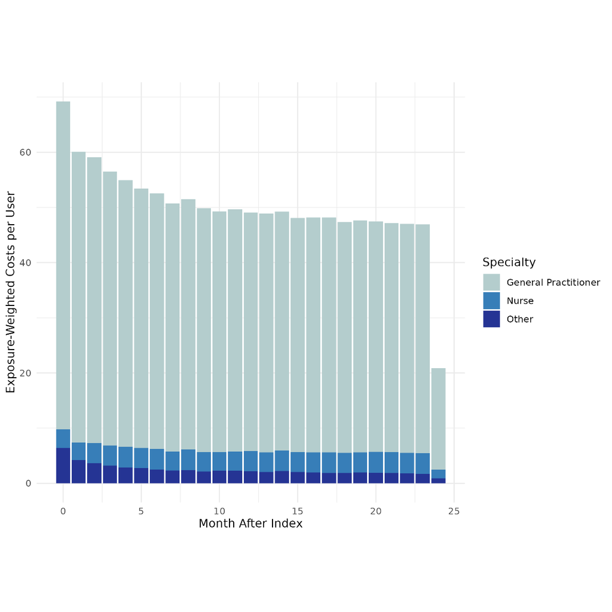

## Costs - OMOP

### Costs Summary Results

**User Only Cost Summary Statistics**

*Subjects Who Visited a Clinically Relevant Consultant*

| Mean Visit Costs per Year | Minimum Visit Costs per Year | Maximum Visit Costs per Year | SD Visit Costs per Year | Median Visit Costs per Year | Lower Quartile Visit Costs per Year | Upper Quartile Visit Costs per Year |
| --- | --- | --- | --- | --- | --- | --- |
| 525.82 | 2.96 | 60522 | 1215.11 | 455.99 | 227.99 | 854.14 |

**All Patients Costs Summary Statistics**

*Subjects Who Visited Both Clinically Relevant and Non-Relevant Consultants*

| Mean Visit Costs per Year | Minimum Visit Costs per Year | Maximum Visit Costs per Year | SD Visit Costs per Year | Median Visit Costs per Year | Lower Quartile Visit Costs per Year | Upper Quartile Visit Costs per Year |
| --- | --- | --- | --- | --- | --- | --- |
| 510.41 | 0 | 60522 | 1197.5 | 433.4 | 196.01 | 827.29 |

### Cost Figures

Figure 4: Total number of primary care consultation costs

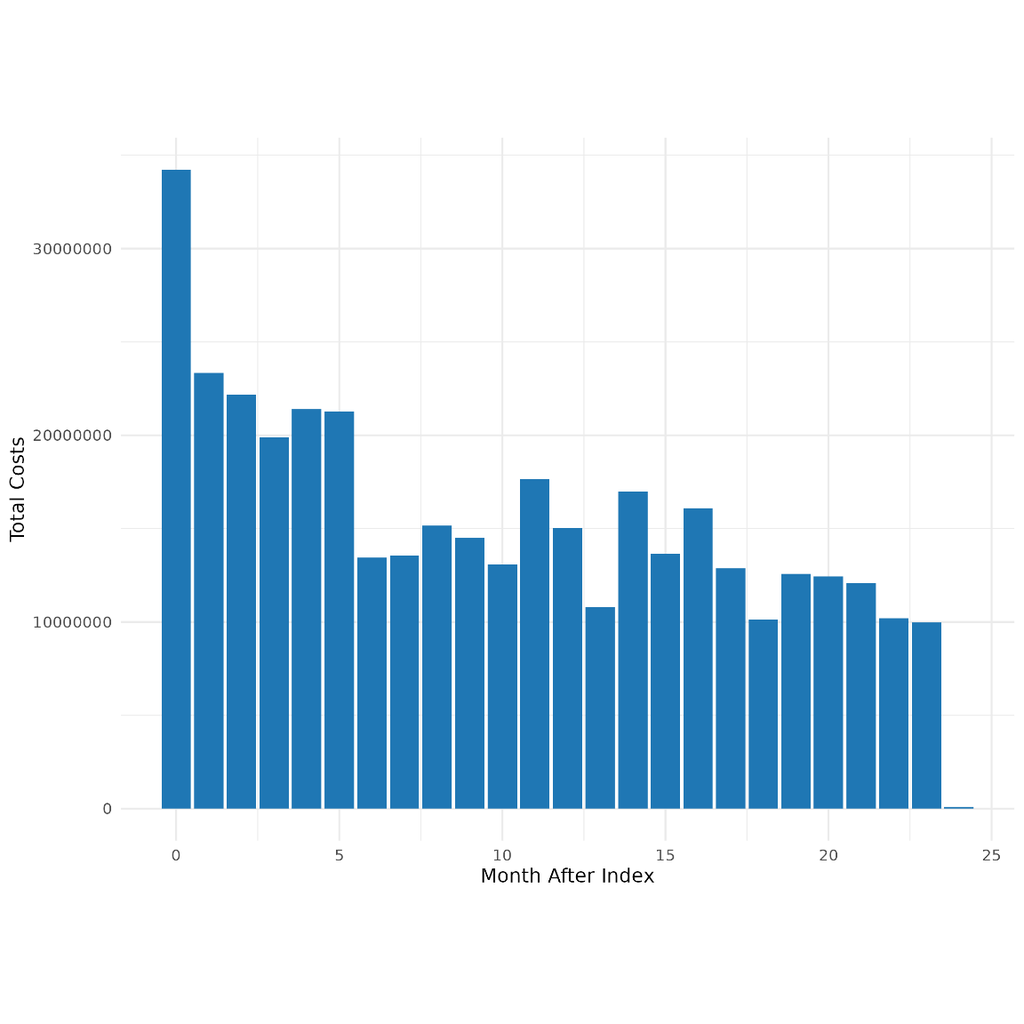

Figure 5: Mean number of primary care consultation costs by provider specialty, users-only.

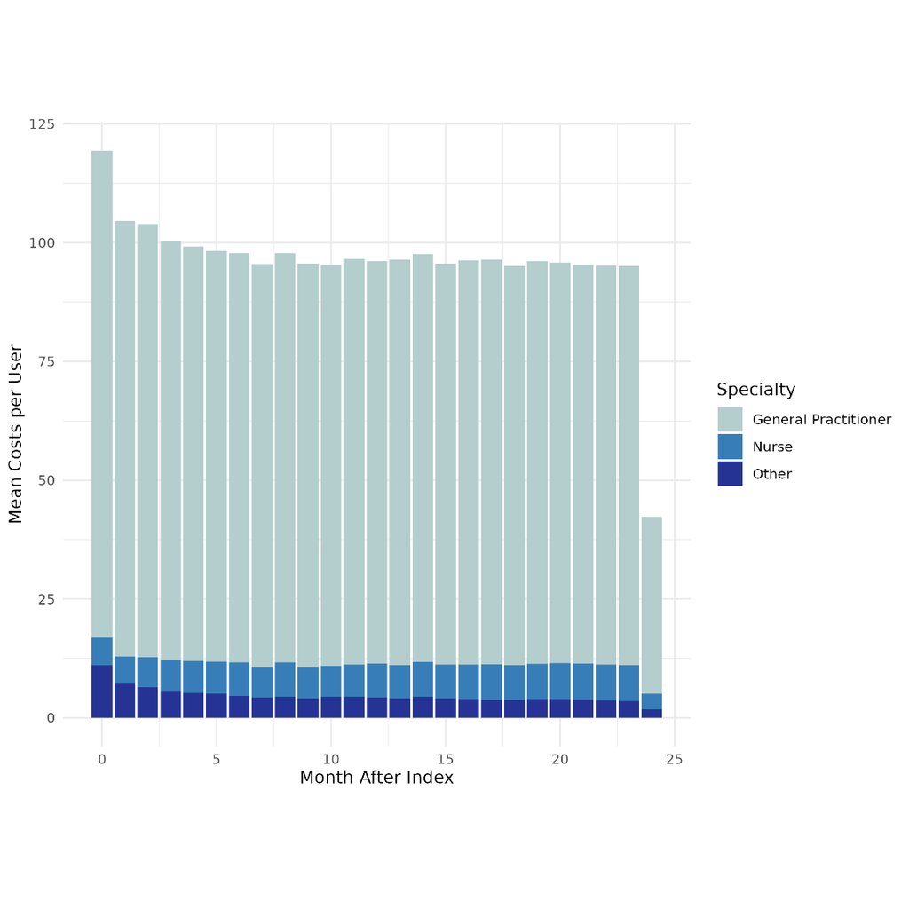

Figure 6: Exposure-weighted mean number of primary care consultations costs by provider specialty, users-only.

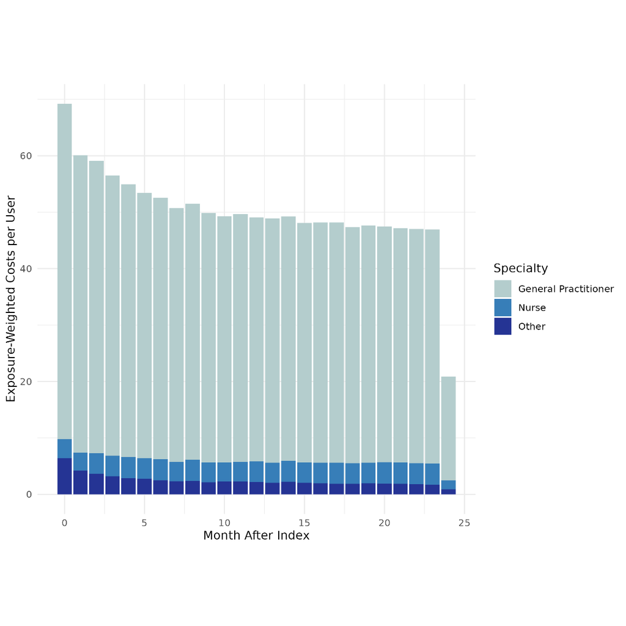

# Appendix

## Raw

### HCRU by Specialty - Users

| Specialty | Total Visits | Mean Visits per Year | SD Visits per Year | Minimum Visits per Year | Maximum Visits per Year | Number of Subjects |
| --- | --- | --- | --- | --- | --- | --- |
| Advanced Practitioner | 523 | 1.89 | 2.55 | 0.5 | 16.79 | 149 |
| Art Therapist | 149 | 3.96 | 6.64 | 0.5 | 26.09 | 22 |
| Art Therapist Consultant | 10 | 1.13 | 0.82 | 0.5 | 2.5 | 5 |
| Art Therapist Specialist Practitioner | 16 | 1.33 | 0.75 | 0.5 | 2.5 | 6 |
| Associate Practitioner | 397 | 1.35 | 1.73 | 0.5 | 10.98 | 157 |
| Associate Practitioner - General Practitioner | 2917 | 2.76 | 5.59 | 0.5 | 79.4 | 590 |
| Associate Practitioner - Nurse | 3226 | 2.06 | 3.59 | 0.5 | 40.58 | 852 |
| Associate Specialist | 302 | 1.77 | 4.13 | 0.5 | 34.6 | 92 |
| Asst. Clinical Medical Officer | 1 | 0.5 |  | 0.5 | 0.5 | 1 |
| Audiologist | 3 | 1.2 | 2.44 | 0.5 | 3.95 | 2 |

[output cut: 58 more lines]

### HCRU by Specialty - All Patients

| Specialty | Total Visits | Mean Visits Per Year | SD Visits Per Year | Minimum Visits Per Year | Maximum Visits Per Year | Number of Subjects |
| --- | --- | --- | --- | --- | --- | --- |
| Advanced Practitioner | 523 | 1.89 | 2.55 | 0.5 | 16.79 | 149 |
| Art Therapist | 149 | 3.96 | 6.64 | 0.5 | 26.09 | 22 |
| Art Therapist Consultant | 10 | 1.13 | 0.82 | 0.5 | 2.5 | 5 |
| Art Therapist Specialist Practitioner | 16 | 1.33 | 0.75 | 0.5 | 2.5 | 6 |
| Associate Practitioner | 397 | 1.35 | 1.73 | 0.5 | 10.98 | 157 |
| Associate Practitioner - General Practitioner | 2917 | 2.76 | 5.59 | 0.5 | 79.4 | 590 |
| Associate Practitioner - Nurse | 3226 | 2.06 | 3.59 | 0.5 | 40.58 | 852 |
| Associate Specialist | 302 | 1.77 | 4.13 | 0.5 | 34.6 | 92 |
| Asst. Clinical Medical Officer | 1 | 0.5 |  | 0.5 | 0.5 | 1 |
| Audiologist | 3 | 1.2 | 2.44 | 0.5 | 3.95 | 2 |

[output cut: 59 more lines]

### Costs by Specialty - Users

| Specialty | Total Visit Costs | Mean Visit Costs Per Year | SD Visit Costs Per Year | Minimum Visit Costs Per Year | Maximum Visit Costs Per Year | Number of Subjects |
| --- | --- | --- | --- | --- | --- | --- |
| Advanced Practitioner | 13987.85 | 50.62 | 68.14 | 13.38 | 449.14 | 149 |
| Art Therapist | 7897 | 209.88 | 351.95 | 26.52 | 1382.73 | 22 |
| Art Therapist Consultant | 530 | 59.77 | 43.48 | 26.52 | 132.59 | 5 |
| Art Therapist Specialist Practitioner | 848 | 70.72 | 39.92 | 26.52 | 132.59 | 6 |
| Associate Practitioner | 12592.84 | 42.77 | 55.01 | 15.87 | 348.15 | 157 |
| Associate Practitioner - General Practitioner | 122514 | 116.02 | 234.6 | 21.01 | 3334.89 | 590 |
| Associate Practitioner - Nurse | 61926.79 | 39.45 | 68.97 | 9.6 | 779.04 | 852 |
| Associate Specialist | 9579.44 | 56.14 | 131.07 | 15.87 | 1097.6 | 92 |
| Asst. Clinical Medical Officer | 42 | 21.01 |  | 21.01 | 21.01 | 1 |
| Audiologist | 348.3 | 139.03 | 283.09 | 58.09 | 458.44 | 2 |

[output cut: 58 more lines]

### Costs by Specialty - All Patients

| Specialty | Total Visit Costs | Mean Visits Per Year | SD Visit Costs Per Year | Minimum Visits Per Year | Maximum Visits Per Year | Number of Subjects |
| --- | --- | --- | --- | --- | --- | --- |
| Advanced Practitioner | 13987.85 | 50.62 | 68.14 | 13.38 | 449.14 | 149 |
| Art Therapist | 7897 | 209.88 | 351.95 | 26.52 | 1382.73 | 22 |
| Art Therapist Consultant | 530 | 59.77 | 43.48 | 26.52 | 132.59 | 5 |
| Art Therapist Specialist Practitioner | 848 | 70.72 | 39.92 | 26.52 | 132.59 | 6 |
| Associate Practitioner | 12592.84 | 42.77 | 55.01 | 15.87 | 348.15 | 157 |
| Associate Practitioner - General Practitioner | 122514 | 116.02 | 234.6 | 21.01 | 3334.89 | 590 |
| Associate Practitioner - Nurse | 61926.79 | 39.45 | 68.97 | 9.6 | 779.04 | 852 |
| Associate Specialist | 9579.44 | 56.14 | 131.07 | 15.87 | 1097.6 | 92 |
| Asst. Clinical Medical Officer | 42 | 21.01 |  | 21.01 | 21.01 | 1 |
| Audiologist | 348.3 | 139.03 | 283.09 | 58.09 | 458.44 | 2 |

[output cut: 59 more lines]

## OMOP

### HCRU by Specialty - Users

| Specialty | Total Visits | Mean Visits per Year | SD Visits per Year | Minimum Visits per Year | Maximum Visits per Year | Number of Subjects |
| --- | --- | --- | --- | --- | --- | --- |
| Advanced Practitioner | 289 | 1.88 | 2.77 | 0.49 | 16.56 | 88 |
| Art Therapist | 82 | 3.83 | 7.44 | 0.49 | 25.73 | 13 |
| Art Therapist Consultant | 8 | 1.62 | 0.82 | 0.99 | 2.47 | 3 |
| Art Therapist Specialist Practitioner | 16 | 1.32 | 0.74 | 0.49 | 2.47 | 6 |
| Associate Practitioner | 270 | 1.2 | 2.14 | 0.49 | 15.14 | 122 |
| Associate Practitioner - General Practitioner | 2073 | 2.79 | 5.3 | 0.49 | 37.27 | 439 |
| Associate Practitioner - Nurse | 1894 | 1.78 | 3.65 | 0.49 | 39.24 | 598 |
| Associate Specialist | 189 | 1.71 | 4.74 | 0.49 | 34.13 | 60 |
| Asst. Clinical Medical Officer | 1 | 0.49 |  | 0.49 | 0.49 | 1 |
| Audiologist | 2 | 4.24 |  | 4.24 | 4.24 | 1 |

[output cut: 56 more lines]

### HCRU by Specialty - All Patients

| Specialty | Total Visits | Mean Visits Per Year | SD Visits Per Year | Minimum Visits Per Year | Maximum Visits Per Year | Number of Subjects |
| --- | --- | --- | --- | --- | --- | --- |
| Advanced Practitioner | 289 | 1.88 | 2.77 | 0.49 | 16.56 | 88 |
| Art Therapist | 82 | 3.83 | 7.44 | 0.49 | 25.73 | 13 |
| Art Therapist Consultant | 8 | 1.62 | 0.82 | 0.99 | 2.47 | 3 |
| Art Therapist Specialist Practitioner | 16 | 1.32 | 0.74 | 0.49 | 2.47 | 6 |
| Associate Practitioner | 270 | 1.2 | 2.14 | 0.49 | 15.14 | 122 |
| Associate Practitioner - General Practitioner | 2073 | 2.79 | 5.3 | 0.49 | 37.27 | 439 |
| Associate Practitioner - Nurse | 1894 | 1.78 | 3.65 | 0.49 | 39.24 | 598 |
| Associate Specialist | 189 | 1.71 | 4.74 | 0.49 | 34.13 | 60 |
| Asst. Clinical Medical Officer | 1 | 0.49 |  | 0.49 | 0.49 | 1 |
| Audiologist | 2 | 4.24 |  | 4.24 | 4.24 | 1 |

[output cut: 57 more lines]

### Costs by Specialty - Users

| Specialty | Total Visit Costs | Mean Visit Costs Per Year | SD Visit Costs Per Year | Minimum Visit Costs Per Year | Maximum Visit Costs Per Year | Number of Subjects |
| --- | --- | --- | --- | --- | --- | --- |
| Advanced Practitioner | 7729.42 | 50.35 | 74.17 | 13.2 | 442.99 | 88 |
| Art Therapist | 4346 | 203.2 | 394.1 | 26.16 | 1363.8 | 13 |
| Art Therapist Consultant | 424 | 85.86 | 43.29 | 52.31 | 130.78 | 3 |
| Art Therapist Specialist Practitioner | 848 | 69.75 | 39.38 | 26.16 | 130.78 | 6 |
| Associate Practitioner | 8564.4 | 37.98 | 67.88 | 15.65 | 480.13 | 122 |
| Associate Practitioner - General Practitioner | 87066 | 117.09 | 222.77 | 20.73 | 1565.22 | 439 |
| Associate Practitioner - Nurse | 36357.52 | 34.18 | 70.03 | 9.47 | 753.16 | 598 |
| Associate Specialist | 5995.08 | 54.37 | 150.29 | 15.65 | 1082.57 | 60 |
| Asst. Clinical Medical Officer | 42 | 20.73 |  | 20.73 | 20.73 | 1 |
| Audiologist | 232.2 | 492.06 |  | 492.06 | 492.06 | 1 |

[output cut: 56 more lines]

### Costs by Specialty - All Patients

| Specialty | Total Visit Costs | Mean Visits Per Year | SD Visit Costs Per Year | Minimum Visits Per Year | Maximum Visits Per Year | Number of Subjects |
| --- | --- | --- | --- | --- | --- | --- |
| Advanced Practitioner | 7729.42 | 50.35 | 74.17 | 13.2 | 442.99 | 88 |
| Art Therapist | 4346 | 203.2 | 394.1 | 26.16 | 1363.8 | 13 |
| Art Therapist Consultant | 424 | 85.86 | 43.29 | 52.31 | 130.78 | 3 |
| Art Therapist Specialist Practitioner | 848 | 69.75 | 39.38 | 26.16 | 130.78 | 6 |
| Associate Practitioner | 8564.4 | 37.98 | 67.88 | 15.65 | 480.13 | 122 |
| Associate Practitioner - General Practitioner | 87066 | 117.09 | 222.77 | 20.73 | 1565.22 | 439 |
| Associate Practitioner - Nurse | 36357.52 | 34.18 | 70.03 | 9.47 | 753.16 | 598 |
| Associate Specialist | 5995.08 | 54.37 | 150.29 | 15.65 | 1082.57 | 60 |
| Asst. Clinical Medical Officer | 42 | 20.73 |  | 20.73 | 20.73 | 1 |
| Audiologist | 232.2 | 492.06 |  | 492.06 | 492.06 | 1 |

[output cut: 57 more lines]

## Assumptions Underlying Cost Calculations

| Specialty | Specialty Reduced | Unit Cost | Source PSSRU 2023 Unless Stated Otherwise (Assumptions) |
| --- | --- | --- | --- |
| Medical Technical Officer - Pharmacy | Other | 6 | Pharmacy technician (community-based scientific and professional staff band 4) per working hour = £36, assuming 10 mins per encounter |
| Medical Technical Officer | Other | 6 | Pharmacy technician (community-based scientific and professional staff band 4) per working hour = £36, assuming 10 mins per encounter |
| Pre-reg Pharmacist | Other | 6 | Pharmacy technician (community-based scientific and professional staff band 4) per working hour = £36, assuming 10 mins per encounter |
| Radiologist | Other | 11.75 | Band 5 salary per hour = 47 (qualified nurses), assuming 15 min encounter |
| Health Care Support Worker | Other | 19.19615384615385 | Nurse associate practitioner (community), Nurse associate practitioner (Mental Health), Nursery nurse (Community), Band 4. duration of contact 15.5 minutes per surgery consultation based on the 2006/0… |
| Community Nurse | Nurse | 19.19615384615385 | Nurse (Community), Nurse (Schools), Nurse (Learning disabilities), Band 5, Cost per hour face-to-face time, duration of contact 15.5 minutes per surgery consultation based on the 2006/07 UK general pr… |
| Trainee Practitioner | Other | 19.19615384615385 | Nurse (Community), Nurse (Schools), Nurse (Learning disabilities), Band 5, Cost per hour face-to-face time, duration of contact 15.5 minutes per surgery consultation based on the 2006/07 UK general pr… |
| Associate Practitioner - Nurse | Nurse | 19.19615384615385 | Nurse (Community), Nurse (Schools), Nurse (Learning disabilities), Band 5, Cost per hour face-to-face time, duration of contact 15.5 minutes per surgery consultation based on the 2006/07 UK general pr… |
| Trainer | Other | 19.19615384615385 | Nurse (Community), Nurse (Schools), Nurse (Learning disabilities), Band 5, Cost per hour face-to-face time, duration of contact 15.5 minutes per surgery consultation based on the 2006/07 UK general pr… |
| Enrolled Nurse | Nurse | 19.19615384615385 | Nurse (Community), Nurse (Schools), Nurse (Learning disabilities), Band 5, Cost per hour face-to-face time, duration of contact 15.5 minutes per surgery consultation based on the 2006/07 UK general pr… |

[output cut: 79 more lines]